title: “Day 1 Part 2 Exercise Michael Scheriger” date: “2019-09-17” output: html_document

## Load the Gapminder Data

````r
# Here is where your R code goes. ``` opens the code chunk, followed by {r}. Then ``` closes the chunk. When you 'knit' the file, the codes will evaluate.

gapminder <- read.csv(here::here("data/gapminder5.csv"), stringsAsFactors=FALSE)
````

## Check to see if there is data from a given year

```r
years <- unique(gapminder$year)
for (year in c(2002,2012)){
  if (any(years == year)){
    print(paste0("There is data from the year ", year))
  }
  else{
    print(paste0("There is not data from the year ", year))
  }
}
```

```
## [1] "There is data from the year 2002"
## [1] "There is not data from the year 2012"
```

## Mean life expectancy for countries with below average population.

```r
avg_pop = mean(gapminder$pop)
for (c in unique(gapminder$country)){
  c_pop = mean(gapminder$pop[gapminder$country == c])
  if(c_pop < avg_pop){
    mean_le <- mean(gapminder$lifeExp[gapminder$country == c])
    print(paste0("The average life expectancy for ",c," is: ",mean_le))
  }
}
```

```
## [1] "The average life expectancy for Afghanistan is: 37.4788333333333"
## [1] "The average life expectancy for Albania is: 68.4329166666667"
## [1] "The average life expectancy for Algeria is: 59.0301666666667"
## [1] "The average life expectancy for Angola is: 37.8835"
## [1] "The average life expectancy for Argentina is: 69.0604166666667"
## [1] "The average life expectancy for Australia is: 74.6629166666667"
## [1] "The average life expectancy for Austria is: 73.10325"
## [1] "The average life expectancy for Bahrain is: 65.6056666666667"
## [1] "The average life expectancy for Belgium is: 73.64175"
## [1] "The average life expectancy for Benin is: 48.7799166666667"
## [1] "The average life expectancy for Bolivia is: 52.5045833333333"
## [1] "The average life expectancy for Bosnia and Herzegovina is: 67.7078333333333"
## [1] "The average life expectancy for Botswana is: 54.5975"
## [1] "The average life expectancy for Bulgaria is: 69.74375"
## [1] "The average life expectancy for Burkina Faso is: 44.694"
```

[output cut: 100 more lines]

## Life Expectancy by Continent

Write a script that loops through the `gapminder` data by continent and prints out whether the mean life expectancy is smaller than 50, between 50 and 70, or greater than 70.

```r
for (c in unique(gapminder$continent)){
  if(mean(gapminder$lifeExp[gapminder$continent==c]) < 50){
    print(paste0(c," has a life expectancy smaller than 50"))
  }
  else if(mean(gapminder$lifeExp[gapminder$continent==c]) > 70){
    print(paste0(c," has a life expectancy greater than 70"))
  }
  else{
    print(paste0(c," has a life expectancy between 50 and 70"))
  }
}
```

```
## [1] "Asia has a life expectancy between 50 and 70"
## [1] "Europe has a life expectancy greater than 70"
## [1] "Africa has a life expectancy smaller than 50"
## [1] "Americas has a life expectancy between 50 and 70"
## [1] "Oceania has a life expectancy greater than 70"
```

## Print column name and class

Create a function that given a data frame will print the name of each column and the class of data it contains. Use the gapminder dataset. Hint: Use `mode()` or `class()` to get the class of the data in each column. Remember that `names()` or `colnames()` returns the name of the columns in a dataset.

```r
print_name_class <- function(df){
  name <- names(df)
  for (n in name){
    print(paste0("Column name is ",n, " and the class is ",class(df[[n]])))
  }
}
```

## Return mean, sd, and (maybe) median

Create a function that given a vector will print the mean and the standard deviation of a **vector**, it will optionally also print the median. Hint: include an argument that takes a boolean (`TRUE`/`FALSE`) operator and then include an `if` statement.

```r
stat_return <- function(vec, med = TRUE){
  print(paste0("Mean of the vector is: ", mean(vec)))
  print(paste0("Standard Deviation of the vector is: ", sd(vec)))
  if (med == TRUE){
    print(paste0("Median of the vector is: ", median(vec)))
  }
}
```

## Analyze GDP Per Capita and Life Expectancy

1. What is the relationship between GDP per capita and life expectancy? Does this relationship change over time? (Hint: Use the natural log of both variables.)

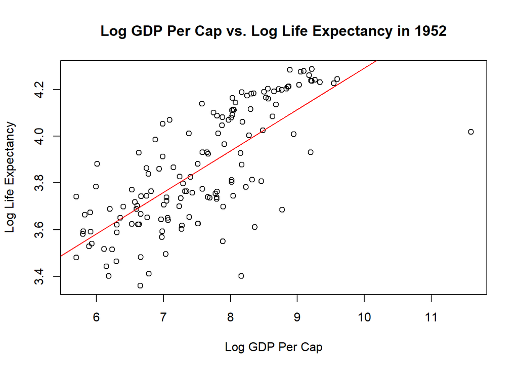

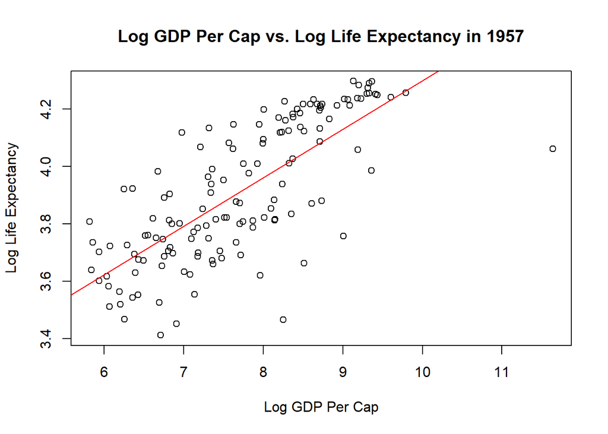

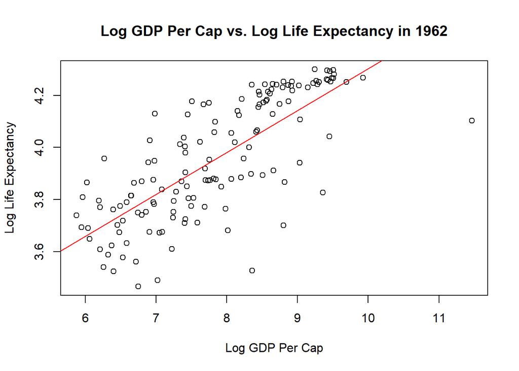

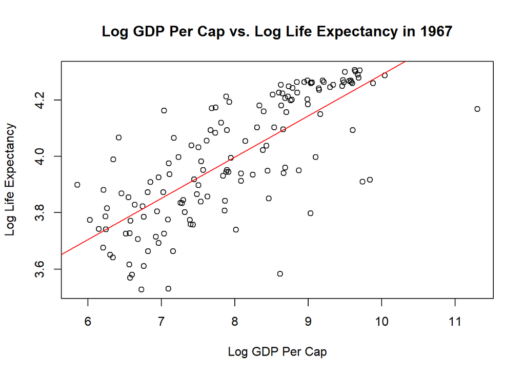

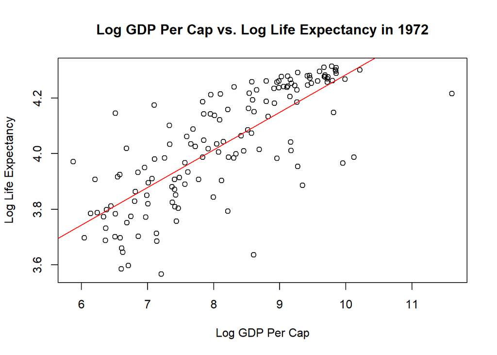

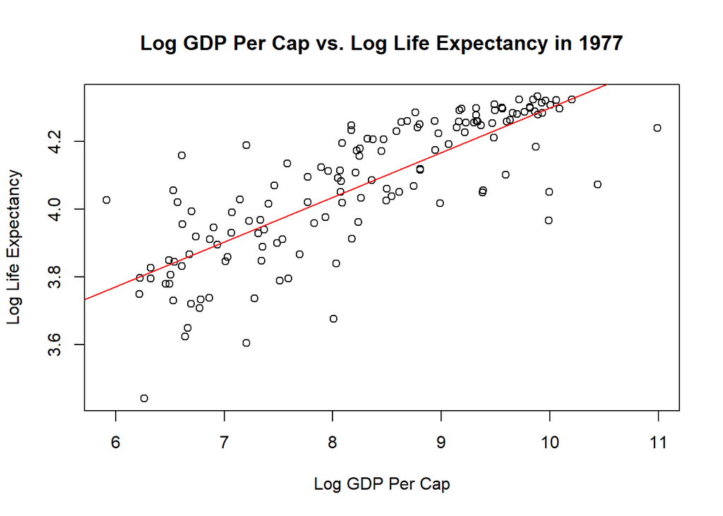

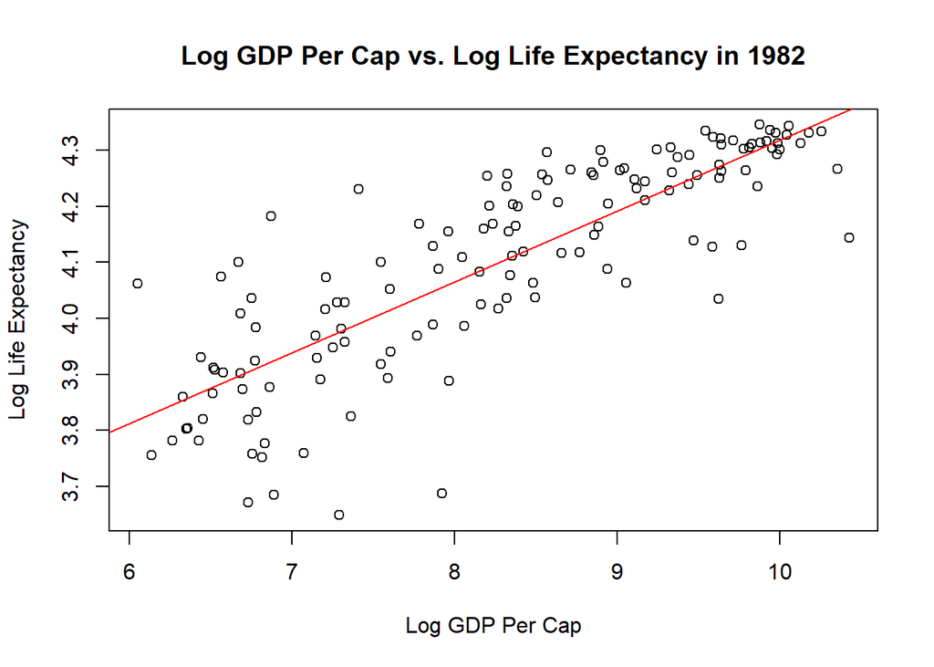

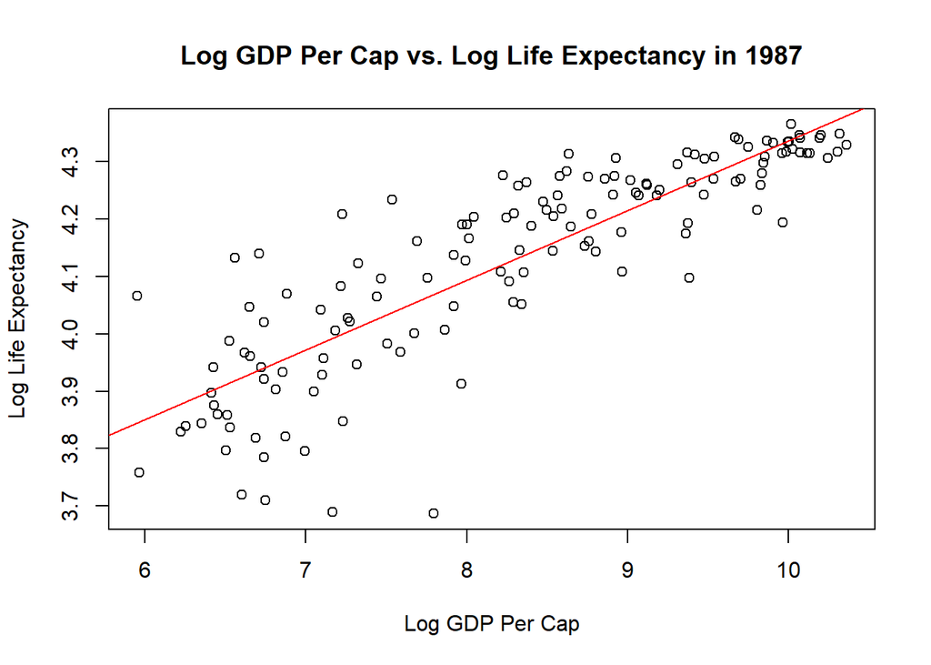

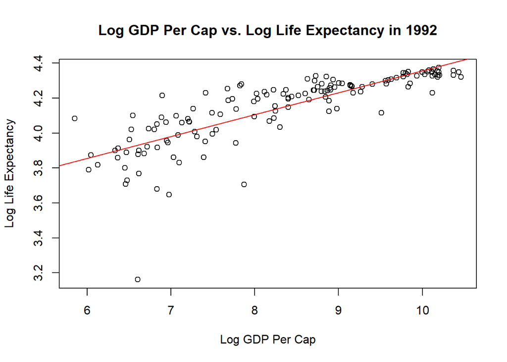

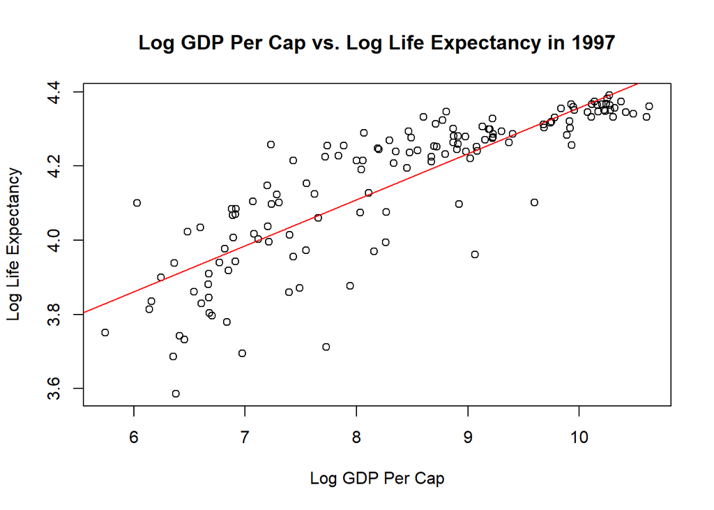

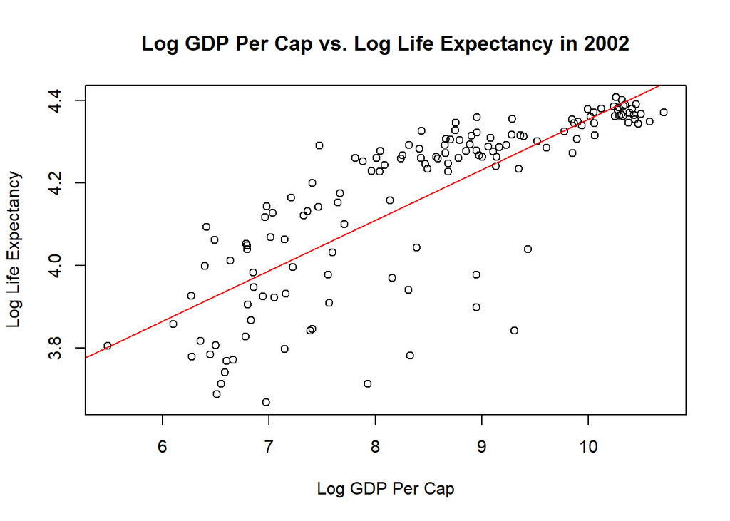

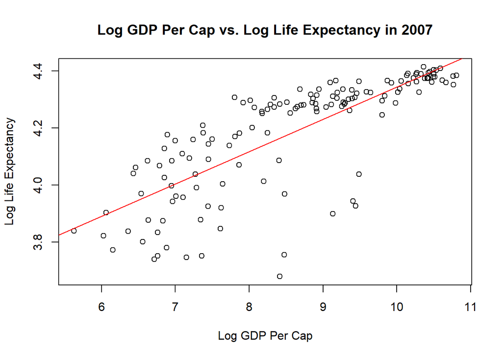

```r
for (year in unique(gapminder$year)){
  g <- gapminder[gapminder$year == year,]
  plot(log(g$gdpPercap),log(g$lifeExp), main = paste0("Log GDP Per Cap vs. Log Life Expectancy in ",year),xlab = "Log GDP Per Cap", ylab = "Log Life Expectancy")
  abline(lm(log(g$lifeExp) ~ log(g$gdpPercap)), col="red")
}
```

## Analyze GDP per capita and life expectancy by Continent

Does the relationship between GDP per capita and life expectacy vary by continent? Make sure you divide the Americas into North and South America.

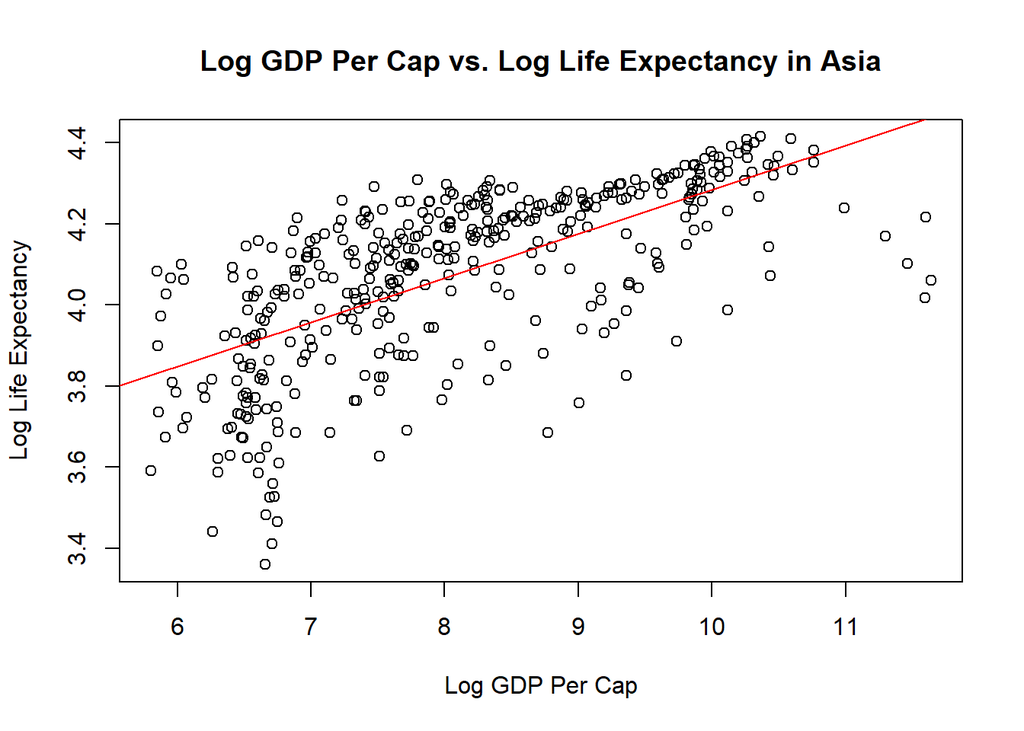

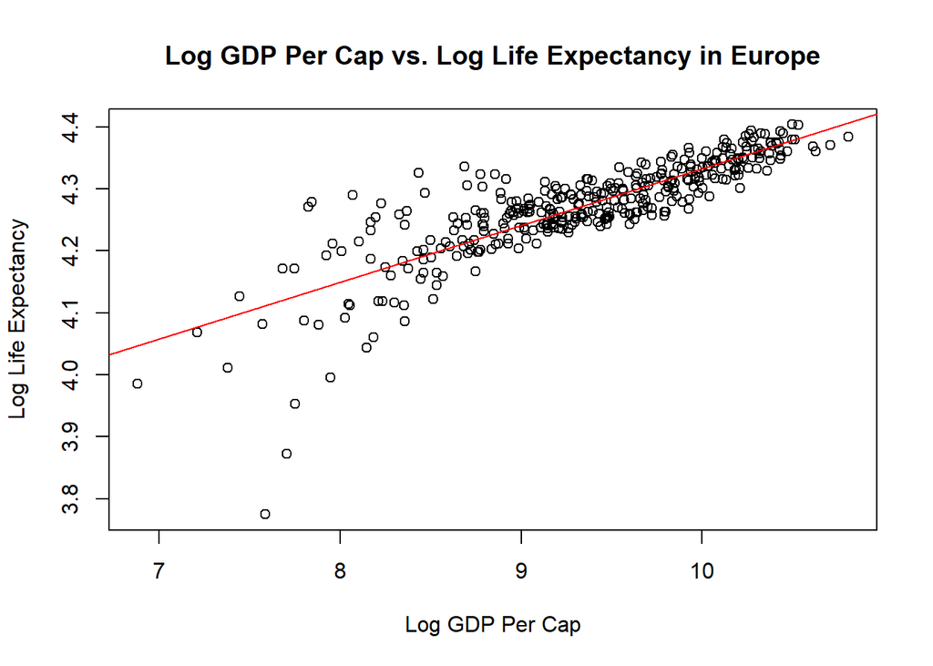

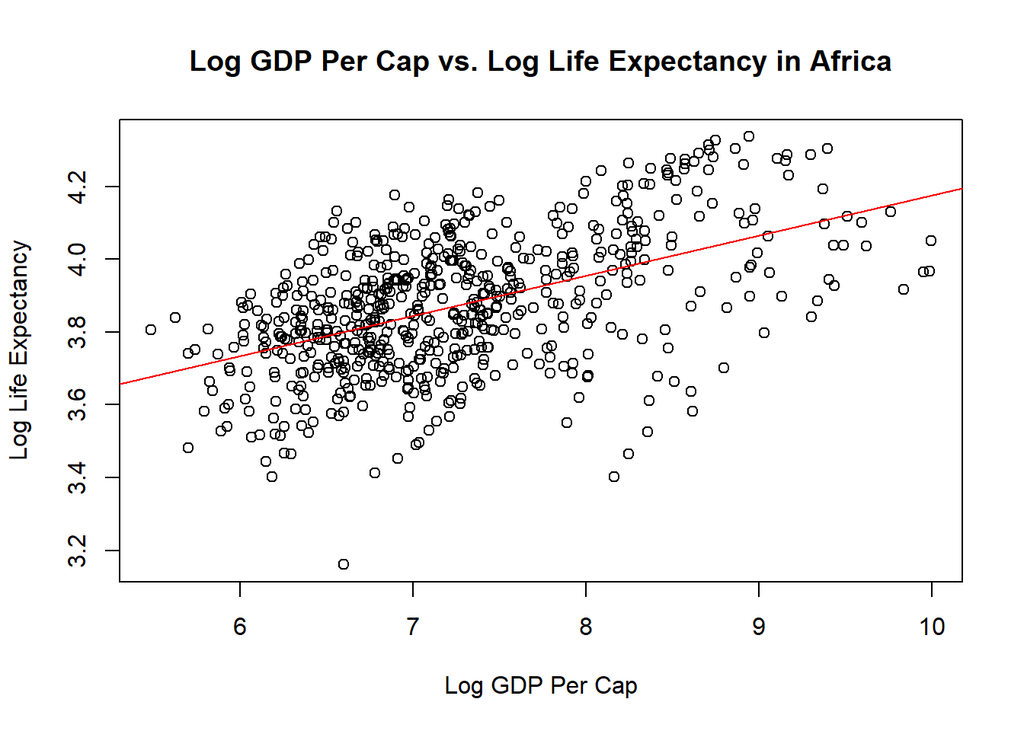

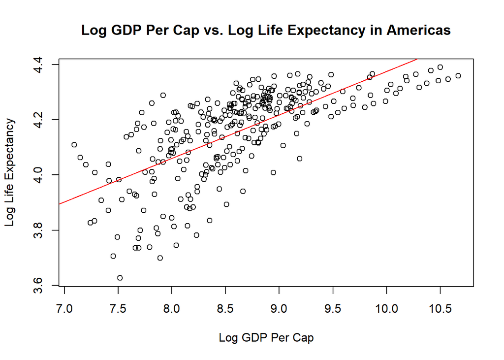

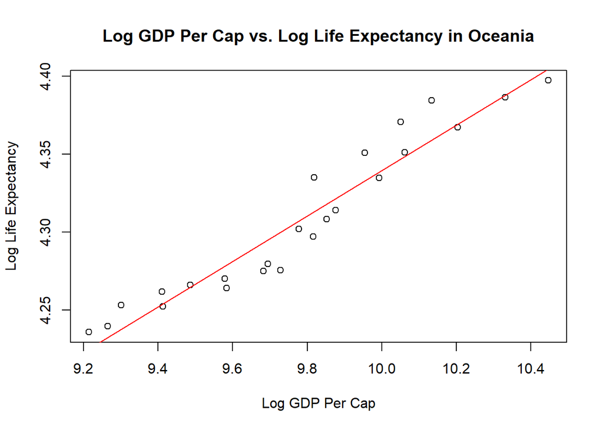

```r
for (c in unique(gapminder$continent)){
  g <- gapminder[gapminder$continent == c,]
  plot(log(g$gdpPercap),log(g$lifeExp), main = paste0("Log GDP Per Cap vs. Log Life Expectancy in ",c),xlab = "Log GDP Per Cap", ylab = "Log Life Expectancy")
  abline(lm(log(g$lifeExp) ~ log(g$gdpPercap)), col="red")
}
```